# ACP, AFC et ACM — Master 2

[figure not shown]

Master 2 — De l’agronomie à l’agroécologie

UE Statistiques

### Analyse en composantes principales

### Analyse factorielle des correspondances

### Analyse des correspondances multiples

## Point de départ : visualiser deux variables

### Rendement en fonction de la dose d’azote

| Parcelle | Azote | Rendement |
| --- | --- | --- |
| 1 | 0 | 4.2 |
| 2 | 50 | 5.1 |
| 3 | 100 | 6.0 |
| 4 | 150 | 6.4 |
| 5 | 200 | 6.5 |

Azote : kg N/ha.  
Rendement : t/ha.

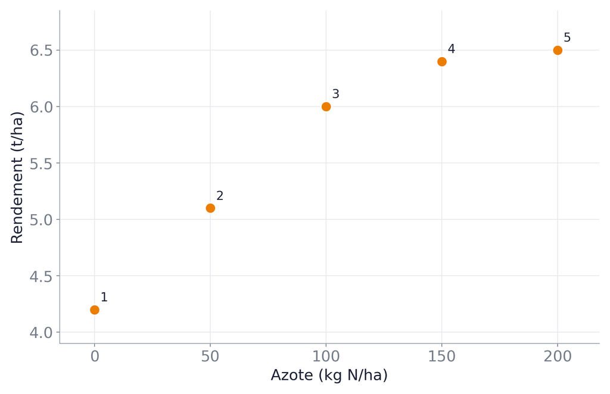

## Point de départ : visualiser trois variables

### Dose d’azote, température moyenne et rendement

| Parcelle | Azote | Temp. | Rend. |
| --- | --- | --- | --- |
| 1 | 0 | 10.5 | 4.0 |
| 2 | 50 | 11.2 | 4.9 |
| 3 | 100 | 12.0 | 6.0 |
| 4 | 150 | 12.8 | 6.7 |
| 5 | 200 | 13.5 | 6.8 |
| 6 | 0 | 13.0 | 4.5 |
| 7 | 50 | 13.8 | 5.5 |
| 8 | 100 | 14.5 | 6.3 |
| 9 | 150 | 15.2 | 6.5 |
| 10 | 200 | 16.0 | 6.2 |

Unités : kg N/ha, °C et t/ha.

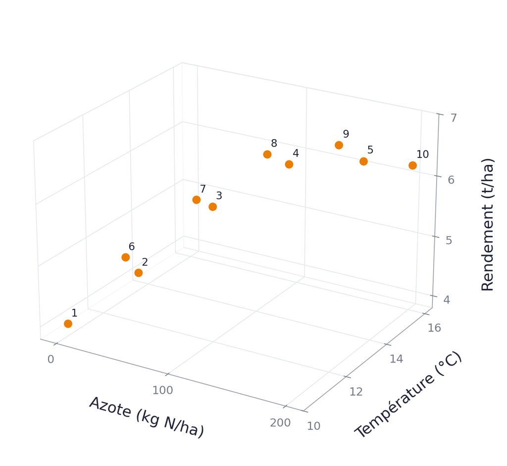

## Et avec cinq variables, ou davantage ?

Rendement en fonction de la dose d’azote, de la température moyenne annuelle, de la couverture du sol, de la quantité d’eau …

### Comment représenter simultanément ces informations ?

Chaque parcelle est un point d’un espace à $p$ dimensions.

Representation en plus de 5 dimensions ? 🫪🫪🫪

## Méthodes de réduction de dimension

### Objectif

Passer de **$p$ variables** à **$q$ variables synthétiques**, avec $q\ll p$ tout en conservant **le maximum d’information** contenue dans les données et en **préservant la distance entre les individus**.

### Exemple concrets :

- **Compression d’une image** : millions de pixels → réduction du nb de pixel (et de la qualité de l’image mais sans qu’elle devienne méconnaissable)
- **Génomique** : milliers de variables → variables génotypique les plus “informatives”

### Une méthode selon le type de données

- **ACP** : plusieurs variables quantitatives.
- **AFC** : une table de contingence croisant deux variables qualitatives.
- **ACM** : plusieurs variables qualitatives décrivant les mêmes individus.

## Types de données

### Tableau de données

| Expl. | Surface | Rend. | Diversité |
| --- | --- | --- | --- |
| 1 | 85 | 6.2 | Faible |
| 2 | 42 | 5.8 | Moyenne |
| 3 | 120 | 7.1 | Faible |
| 4 | 35 | 5.2 | Élevée |
| 5 | 67 | 6.4 | Élevée |
| 6 | 28 | 4.9 | Moyenne |
| 7 | 95 | 6.8 | Faible |
| 8 | 51 | 5.9 | Élevée |

Une ligne = **une exploitation**.  
Variables quantitatives et qualitatives.

### Table de contingence

*Type de production × présence de haies*

| Production | Non | Oui |
| --- | --- | --- |
| Grandes cultures | 12 | 4 |
| Polyculture-élevage | 5 | 15 |
| Maraîchage | 2 | 10 |
| Arboriculture | 3 | 8 |

Une case = **un effectif**.  
Deux variables qualitatives croisées.

## Rappels : representation matricielle des individus et variables

On observe **$n$ individus** décrits par **$p$ variables**.

$${\color{blue}{X}} =
\begin{array}{c|cccc}
& v_1 & v_2 & \cdots & v_p \\
\hline
x_1 & \color{blue}{x_{11}} & \color{blue}{x_{12}} & \cdots & \color{blue}{x_{1p}} \\
x_2 & \color{blue}{x_{21}} & \color{blue}{x_{22}} & \cdots & \color{blue}{x_{2p}} \\
\vdots & \vdots & \vdots & \ddots & \vdots \\
x_n & \color{blue}{x_{n1}} & \color{blue}{x_{n2}} & \cdots & \color{blue}{x_{np}}
\end{array}$$

- **Colonnes** : variables, par exemple azote, rendement, température, surface.
- **Lignes** : individus, par exemple parcelles, exploitations ou années.

## Rappels : moyenne, variance et distance

### Moyenne empirique d’une variable $v_j$

$$\bar v_j=\frac1n\sum_{i=1}^n x_{ij}.$$

### Variance empirique d’une variable $v_j$

$$s_j^2=\frac1n\sum_{i=1}^n(x_{ij}-\bar v_j)^2.$$

### Covariance empirique entre deux variables $v_j$ et $v_k$

$$s_{jk}=\frac1n\sum_{i=1}^n(x_{ij}-\bar v_j)(x_{ik}-\bar v_k).$$

### Distance euclidienne entre deux **individus**

$$d(x_i,x_{i'})=\sqrt{\sum_{j=1}^{p}\bigl(x_{ij}-x_{i'j}\bigr)^2}.$$

La distance dépend des unités choisies.

## ACP préliminaires : centrer et choisir les échelles

### Centrer les variables

$$\tilde{x}_{ij} = x_{ij}-\bar v_j.$$

Le centre du nuage devient l’origine.

### Réduire si les échelles ne sont pas comparables

$$\tilde{x}_{ij}=\frac{x_{ij}-\bar v_j}{s_j}\qquad(s_j>0).$$

Chaque variable a alors une variance égale à 1. On évite, par exemple, que les unités de surface prennent le dessus sur celles du rendement.

## ACP : formalisation du problème

Pour les variables centrées (éventuellement réduites), on cherche

$$z_k=a_{1k}v_1+\cdots+a_{pk}v_p,\qquad k=1,\ldots,p.$$

telles que les $z_k$ soient

- de variance maximale parmi toutes les combinaisons linéaires possibles des $v_1, \dots, v_p$
- non corrélées

Les composantes sont **non corrélées entre elles** et leurs variances décroissent :

$$\operatorname{Cov}(z_k,z_\ell)=0\ (k\ne\ell),\qquad
\operatorname{Var}(z_1)\ge\cdots\ge\operatorname{Var}(z_q).$$

- Les variables **$z_1, \dots, z_q$ sont appelées composantes principales**.
- Ce problème est résolu par l’algèbre linéaire.

La variance d’un axe est calculée à partir des coordonnées des points sur cet axe.

## Aparté : diagonaliser une matrice symétrique

Diagonaliser une matrice réelle symétrique $A$ consiste à écrire

$$A=P\Lambda P^\top,\qquad P^\top P=I.$$

- Les colonnes de $P$ sont des **vecteurs propres orthonormés**.
- La diagonale de $\Lambda$ contient les **valeurs propres**.

Par exemple, pour $A=\begin{pmatrix}2&1\\1&3\end{pmatrix}$, les valeurs propres sont

$$\lambda_1=\frac{5+\sqrt5}{2},\qquad
\lambda_2=\frac{5-\sqrt5}{2}.$$
—

## ACP : covariance ou corrélation

On diagonalise une matrice **$p\times p$**, construite à partir des variables.

### Matrice de covariance

$$\Sigma=\begin{pmatrix}
s_1^2&s_{12}&\cdots&s_{1p}\\
s_{21}&s_2^2&\cdots&s_{2p}\\
\vdots&\vdots&\ddots&\vdots\\
s_{p1}&s_{p2}&\cdots&s_p^2
\end{pmatrix}.$$

Les variables conservent leurs **unités d’origine**.

### Matrice de corrélation

$$R=\begin{pmatrix}
1&r_{12}&\cdots&r_{1p}\\
r_{21}&1&\cdots&r_{2p}\\
\vdots&\vdots&\ddots&\vdots\\
r_{p1}&r_{p2}&\cdots&1
\end{pmatrix},\quad r_{jk}=\frac{s_{jk}}{s_js_k}.$$

Les variables sont **centrées et réduites**.

**Attention ! On ne diagonalise pas le tableau de données $X$.**

## ACP : axes principaux et variance expliquée

$$\Sigma=P\Lambda P^\top\qquad\text{ou}\qquad R=P\Lambda P^\top.$$

- **Vecteurs propres** : directions des axes principaux.
- **Valeurs propres** $\lambda_1\ge\cdots\ge\lambda_p\ge0$ : variances des composantes.
- **Part de variance expliquée** par les $q$ premiers axes :

$$\frac{\lambda_1+\cdots+\lambda_q}{\lambda_1+\cdots+\lambda_p}.$$

On choisit $q$ pour obtenir une représentation lisible qui restitue une part suffisante de la variabilité.

## ACP : repérer les axes principaux

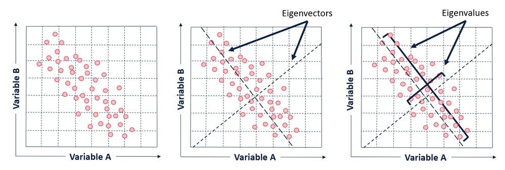

Les directions principales suivent les directions de plus grande dispersion du nuage.

## ACP : changer de repère, puis projeter

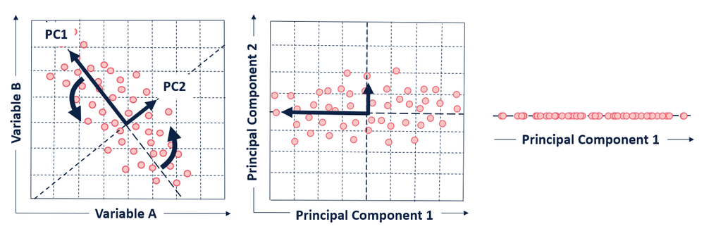

Le changement de repère conserve l’information. **La projection sur moins d’axes élimine la variabilité portée par les axes écartés.**

## Notions qui seront abordées en complément en TP

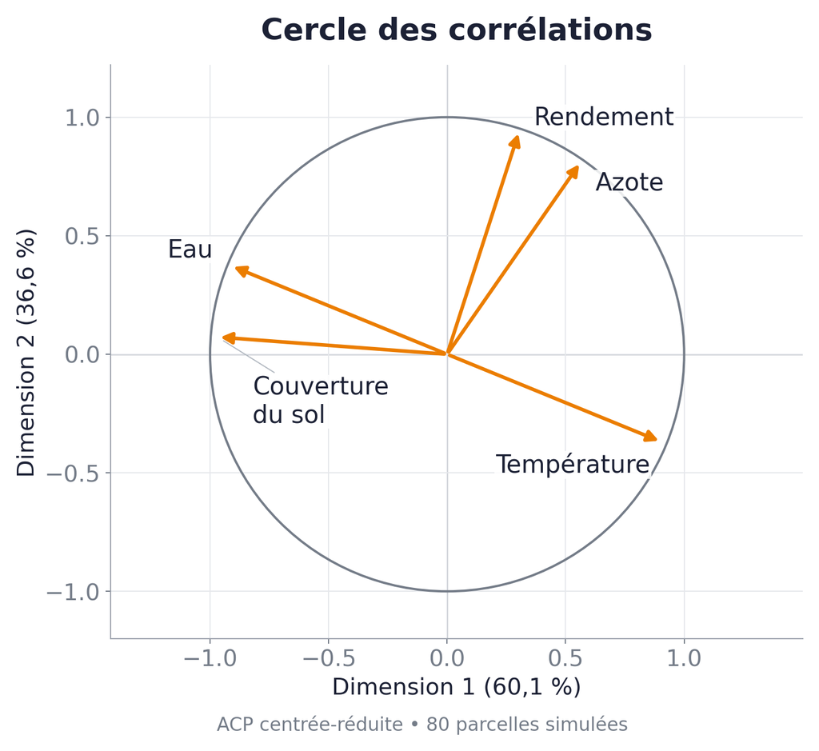

### Lire le cercle des corrélations

- Comprendre les coordonnées des flèches : corrélations avec les axes.
- Interpréter **les angles** : même sens, sens opposé, angle droit.
- Vérifier la **qualité de représentation** ($\cos^2$) avant de conclure.
- Lire contributions et variance expliquée ; choisir les axes retenus.

**Le cosinus de l’angle approche la corrélation si les deux variables sont bien représentées dans le plan.**

## AFC : étudier les liens entre deux variables qualitatives

**Analyse factorielle des correspondances (AFC).** On part d’une table de contingence : chaque case compte les individus qui possèdent les deux modalités.

| Type de production | Absence de haies | Présence de haies | Total |
| --- | --- | --- | --- |
| Grandes cultures | 12 | 4 | 16 |
| Polyculture-élevage | 5 | 15 | 20 |
| Maraîchage | 2 | 10 | 12 |
| Arboriculture | 3 | 8 | 11 |
| **Total** | **22** | **37** | **59** |

- Les exploitations en grandes cultures sont-elles associées à l’absence de haies ?
- La polyculture-élevage est-elle associée à la présence de haies ?
- Le maraîchage et l’arboriculture présentent-ils des profils similaires ?

**L’AFC réduit la dimension des profils pour représenter les écarts à l’indépendance.**

## AFC : une géométrie adaptée aux tables de contingence

**Le même exemple**, avec $n=59$ :

| Type de production | Absence de haies | Présence de haies | Total |
| --- | --- | --- | --- |
| Grandes cultures | 12 | 4 | 16 |
| Polyculture-élevage | 5 | 15 | 20 |
| Maraîchage | 2 | 10 | 12 |
| Arboriculture | 3 | 8 | 11 |
| **Total** | **22** | **37** | **59** |

On utilise les **fréquences marginales** des lignes et des colonnes.

$$r=\frac{1}{59}\begin{pmatrix}16\\20\\12\\11\end{pmatrix},
\qquad
c=\frac{1}{59}\begin{pmatrix}22\\37\end{pmatrix}.$$

**Matrice des masses des colonnes** :

$$D_c=\operatorname{diag}(c_1,c_2)
=\begin{pmatrix}22/59&0\\0&37/59\end{pmatrix}.$$

De même, $D_r=\operatorname{diag}(r_1,\ldots,r_4)$.

## AFC : comparer des profils

$$f_i=\left(\frac{n_{i1}}{n_{i\cdot}},\ldots,\frac{n_{iJ}}{n_{i\cdot}}\right).$$

Ici, $f_{\mathrm{GC}}=(0{,}75,\,0{,}25)$ et $f_{\mathrm{PE}}=(0{,}25,\,0{,}75)$.

La **distance du $\chi^2$** entre deux profils-lignes est

$$d_{\chi^2}^2(i,i')
=\sum_{j=1}^{J}\frac{(f_{ij}-f_{i'j})^2}{c_j}.$$

## AFC : mesurer les écarts à l’indépendance

Sous l’indépendance, l’effectif attendu dans la case $(i,j)$ est

$$e_{ij}=\frac{n_{i\cdot}n_{\cdot j}}{n}=n r_i c_j.$$

**Grandes cultures × absence de haies** :

$$e_{\mathrm{GC, Abs}}=\frac{16\times22}{59}\simeq5{,}97, \text{ alors qu'on a}
\qquad n_{\mathrm{GC, Abs}}=12.$$

Cette combinaison est donc **surreprésentée dans le tableau**.

$$\chi^2=\sum_{i,j}\frac{(n_{ij}-e_{ij})^2}{e_{ij}},
\qquad \text{inertie totale de la table de contingence}=\frac{\chi^2}{n}.$$

L’AFC décompose cet écart global selon des directions interprétables.

## AFC : de la table de contingence aux axes factoriels

On pose $P=N/n$, puis on centre et on pondère les écarts :

$$S=D_r^{-1/2}(P-r c^\top)D_c^{-1/2}.$$

La matrice $S$, généralement rectangulaire, admet une **décomposition en valeurs singulières** :

$$S=U\operatorname{diag}(\sigma_1,\ldots,\sigma_q)V^\top,
\qquad \sigma_1\geq\cdots\geq\sigma_q>0.$$

- $U$ et $V$ permettent de construire les coordonnées des lignes et des colonnes.
- L’axe $k$ porte l’inertie $\lambda_k=\sigma_k^2$.
- On conserve les premiers axes pour résumer au mieux le tableau.

**Au plus $\min(I-1,J-1)$ axes non nuls : notre tableau $4\times2$ n’en a qu’un.**

## AFC : un exemple à deux dimensions

Pour visualiser deux axes, on étend l’exemple : les haies présentes sont séparées en « discontinues » et « continues ».

| Type de production | Absentes | Discontinues | Continues | Total |
| --- | --- | --- | --- | --- |
| Grandes cultures | 12 | 3 | 1 | 16 |
| Polyculture-élevage | 5 | 8 | 7 | 20 |
| Maraîchage | 2 | 2 | 8 | 12 |
| Arboriculture | 3 | 5 | 3 | 11 |
| **Total** | **22** | **18** | **19** | **59** |

La table devient $4\times3$ : **deux axes non nuls sont maintenant possibles**.

Les effectifs « absence / présence » initiaux sont conservés en regroupant les deux dernières colonnes.

## AFC : le nuage des profils

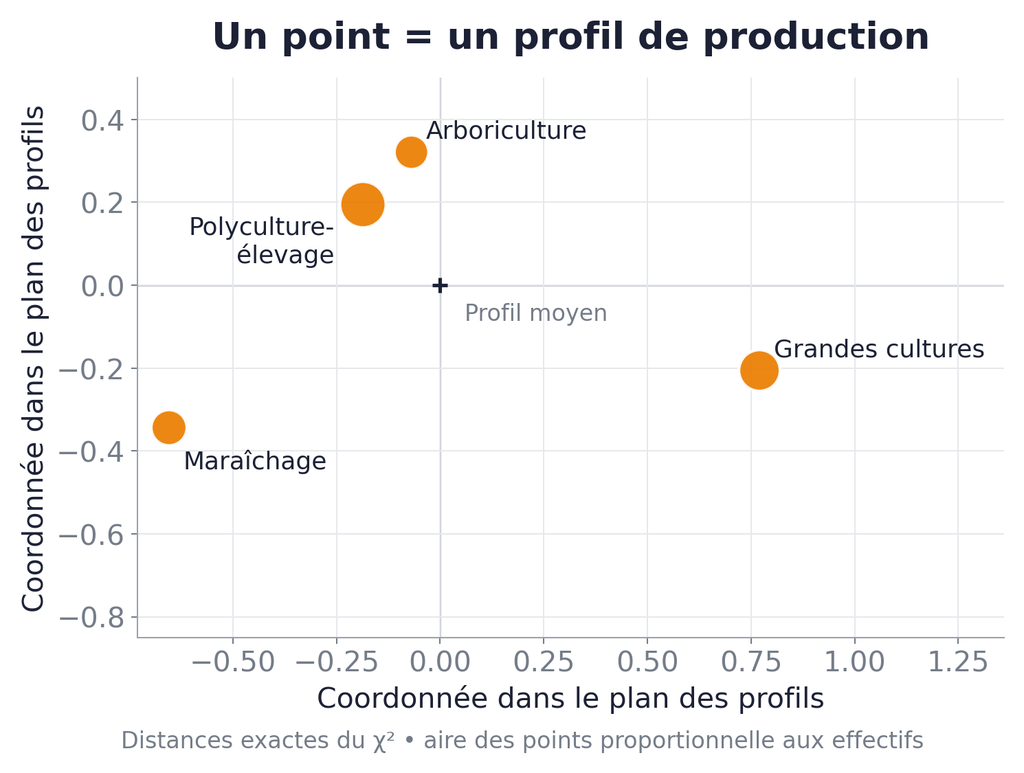

- Un point représente un **type de production**.
- Sa position résume son profil de haies.
- Les distances représentent les différences de profils au sens du $\chi^2$.

**L’origine représente le profil moyen.**

## AFC : choisir les axes factoriels

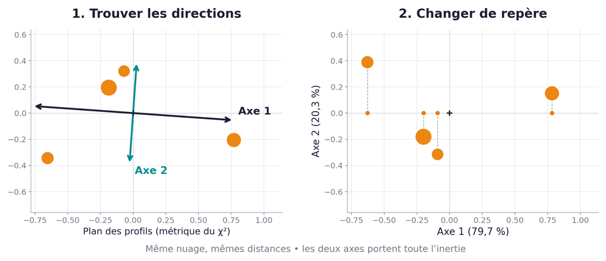

**Comme en ACP** : l’axe 1 maximise l’inertie ; l’axe 2 maximise l’inertie restante dans une direction orthogonale. La dispersion est pondérée par les **masses des lignes**.

## AFC : notions qui seront abordées en TP

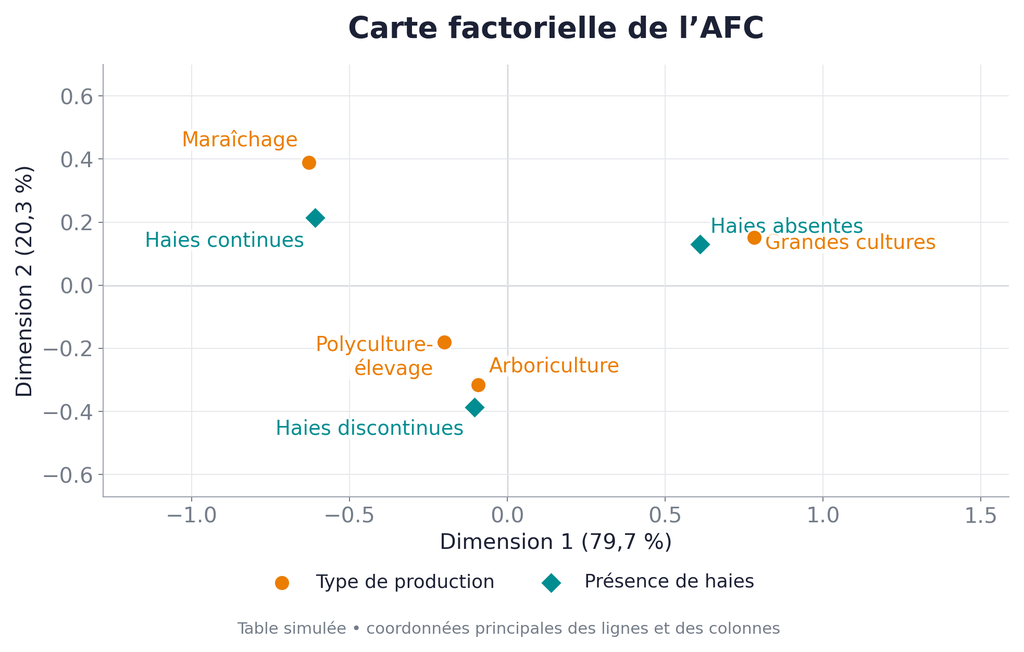

- Lire les **pourcentages d’inertie**.
- Comparer les profils des lignes, puis ceux des colonnes.
- Repérer les modalités qui **construisent les axes**.
- Vérifier la **qualité de représentation**.

## ACM : plusieurs variables qualitatives

L’**analyse des correspondances multiples (ACM)** décrit simultanément les individus et les modalités de plusieurs variables qualitatives.

On complète les données sur les exploitations de l’exemple simulé par une variable de **diversité des cultures**.

| Variable | Modalités |
| --- | --- |
| Type de production | Grandes cultures, Polyculture-élevage, Maraîchage, Arboriculture |
| Haies | Absentes, Discontinues, Continues |
| Diversité des cultures | Faible, Moyenne, Élevée |

- Quelles exploitations ont des **profils proches** ?
- Quelles modalités caractérisent les **principales différences** entre exploitations ?

## ACM : coder les modalités

On transforme les données en **tableau disjonctif complet** $Z$ :

$$z_{i\ell}=
\begin{cases}
1 & \text{si l'individu }i\text{ possède la modalité }\ell,\\
0 & \text{sinon.}
\end{cases}$$

Exemples de codage du **bloc « Haies »**, qui comporte trois colonnes :

| Modalité de l’exploitation | Absentes | Discontinues | Continues |
| --- | --- | --- | --- |
| Haies absentes | 1 | 0 | 0 |
| Haies discontinues | 0 | 1 | 0 |
| Haies continues | 0 | 0 | 1 |

On juxtapose les blocs des trois variables : ici, **$n$ lignes et 10 colonnes**.

Chaque ligne contient exactement **trois « 1 »**, un par variable. (Ici le trois fait référence aux trois **variables qualitatives** types de production, haies et diversité des cultures)

## ACM : une géométrie pour les profils qualitatifs

L’ACM est une **AFC du tableau disjonctif complet** $Z$.

Si $p$ est le nombre de variables et $a_\ell$ la proportion d’individus possédant la modalité $\ell$, alors

$$d_{\chi^2}^2(i,i')
=\frac{1}{p}\sum_{\ell=1}^{K}
\frac{(z_{i\ell}-z_{i'\ell})^2}{a_\ell}.$$

- Deux individus qui possèdent les mêmes modalités ont une distance nulle.
- Une différence portant sur une modalité rare pèse davantage.
- Tous les individus ont la même masse $1/n$.

**Les axes résument les principales différences entre ces profils.**

## ACM : du codage aux axes factoriels

Le total de $Z$ (la tableau des données) vaut $np$. On pose donc

$$P=\frac{Z}{np},\qquad r_i=\frac1n,\qquad c_\ell=\frac{a_\ell}{p}.$$

On retrouve la même construction que pour l’AFC :

$$S=D_r^{-1/2}(P-r c^\top)D_c^{-1/2}
=U\operatorname{diag}(\sigma_k)V^\top.$$

- Les premiers axes décrivent les oppositions principales entre profils.
- On représente les individus et les modalités pour interpréter ces axes.
- L’inertie de l’axe $k$ est $\lambda_k=\sigma_k^2$.

**Ici, le codage autorise jusqu’à $K-p=7$ axes : le plan ne résume qu’une partie des différences.**

## ACM : notions qui seront abordées en TP

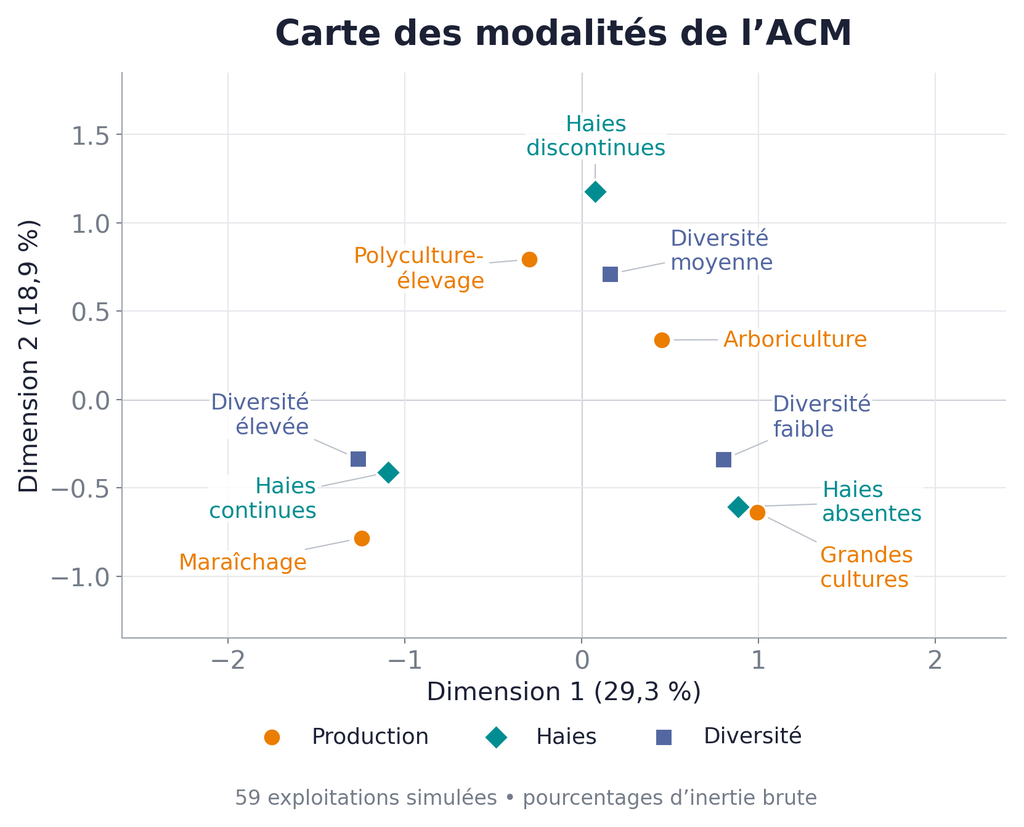

- Interpréter les axes à partir des **modalités qui y contribuent**.
- Lire les proximités avec leur **qualité de représentation**.
- Repérer l’influence des modalités rares.
- Relier la carte des modalités à celle des individus.

**Les modalités sont des points, pas des flèches de corrélation.**

## ACP, AFC ou ACM : quel tableau, quelle question ?

| Méthode | Données | Ce que résument les axes |
| --- | --- | --- |
| **ACP** | Individus × variables quantitatives | Variabilité des mesures |
| **AFC** | Table croisant deux variables qualitatives | Écarts à l’indépendance |
| **ACM** | Individus × plusieurs variables qualitatives | Différences entre profils de modalités |

Dans les trois cas : **choisir les axes (fait avec des outils d’algèbre linéaire), examiner les contributions et vérifier la qualité de représentation**.